# EDA

Team!

4/18/2020

```r
# Clean up R environment
rm(list = ls())

# Load in packages
library(tidyverse) # Data wrangling, ggplot, etc.
library(knitr)     # This is to make pretty tables (see kable() )
library(corrplot)  # Correlation plot

# Read in data
Raw_data <-
  read.csv("./Data/training_set_features.csv", stringsAsFactors=FALSE,
           na.strings=c("","NA")) # Account for blanks being NA
Raw_labels <-
  read.csv("./Data/training_set_labels.csv", stringsAsFactors=FALSE)
Raw_test <-
  read.csv("./Data/test_set_features.csv", stringsAsFactors=FALSE)

# Global options
set.seed(14)
theme_set(theme_bw()) # Set a better ggplot theme
options(digits=3)     # Set digits to 3 to avoid too many values
```

# Data Cleaning

Join the response variables (in Raw_labels) to the training data (Raw_data)

```r
# Since the datasets are in the same order, I just cbind() the two, dropping
#  respondent id in the Raw_labels dataset
Training_full <- cbind(Raw_data, Raw_labels[2:3])
```

Check the total number of NAs for each row. Note that `health_insurance`, `employment_industry`, and `employment_occupation` have a LOT of NAs.

```r
# Total number of NAs
sapply(Training_full, function(x) sum(is.na(x)))
```

```
##               respondent_id                h1n1_concern
##                           0                          92
##              h1n1_knowledge   behavioral_antiviral_meds
##                         116                          71
##        behavioral_avoidance        behavioral_face_mask
##                         208                          19
##       behavioral_wash_hands behavioral_large_gatherings
##                          42                          87
##     behavioral_outside_home       behavioral_touch_face
##                          82                         128
##            doctor_recc_h1n1        doctor_recc_seasonal
##                        2160                        2160
##       chronic_med_condition        child_under_6_months
##                         971                         820
##               health_worker            health_insurance
##                         804                       12274
## opinion_h1n1_vacc_effective           opinion_h1n1_risk
##                         391                         388
## opinion_h1n1_sick_from_vacc opinion_seas_vacc_effective
##                         395                         462
##           opinion_seas_risk opinion_seas_sick_from_vacc
##                         514                         537
##                   age_group                   education
##                           0                        1407
##                        race                         sex
##                           0                           0
##              income_poverty              marital_status
##                        4423                        1408
##                 rent_or_own           employment_status
##                        2042                        1463
##              hhs_geo_region                  census_msa
##                           0                           0
##            household_adults          household_children
##                         249                         249
##         employment_industry       employment_occupation
##                       13330                       13470
##                h1n1_vaccine            seasonal_vaccine
##                           0                           0
```

```r
# For a prettier table format in pdf/html
#kable(sapply(wiki, function(x) sum(is.na(x))), col.names = 'NA Values')
```

Since `health_insurance`, `employment_industry`, and `employment_occupation` have almost half data missing, it might make sense to not include these 3 variables as our potential predictors.

```r
training <- Training_full %>% select(-health_insurance,-employment_industry,-employment_occupation)
```

# General EDA

Basic exploration of the data.

It seems like roughly half of the training observations were vaccinated for the flu, while only ~21% were vaccinated for the h1n1

```r
# Examine how may of the total observations were vaccinated
Raw_labels %>%
  summarize(seasonal_vaccine = sum(seasonal_vaccine),
            h1n1_vaccinated = sum(h1n1_vaccine),
            n = n())
```

```
##   seasonal_vaccine h1n1_vaccinated     n
## 1            12435            5674 26707
```

In addition to the 2 response variables, we also have 32 potential predictors (not including respondent IDs and the 3 variables from above with huge number of NAs). Out of these, 12 are demographic variables. Let’s first look at these demographic variables.

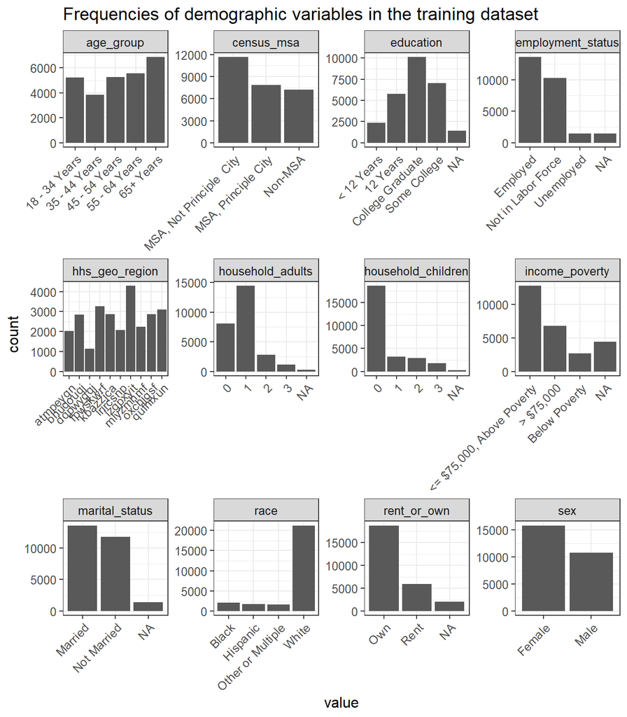

```r
training %>%
  select(age_group:household_children)%>%
  gather() %>%
  ggplot(aes(value)) +
    facet_wrap(~ key, scales = "free") +
    geom_bar()+
    ggtitle("Frequencies of demographic variables in the training dataset")+
    theme(text = element_text(size=12), axis.text.x = element_text(angle=45, hjust=1))
```

Based on the education plot, it looks like most of our respondents have at least some college education. We do have 1407 missing education values though.

We can also see that most of our respondents are either employed or not in the labor force. Respondents not in the labor force are not employed and have stopped looking for work. Only a small number of respondents are unemployed and looking for a job. We also have 1463 missing values here.

Even though our data doesn’t specify the name of the geographical region, it looks like we have decent representation from all 10 geographical regions.

The household variables suggest that most of the respondents live in a household either by themselves or with one other adult. Most of the respondents also have no children in the household. It might make sense to combine household_children and household_adults to create the total household size.

The income data suggests that most respondents are above poverty with a sizeable chunk making over 75,000 USD per year. However, we have 4423 missing values, which may be a sizeable chunk for our prediction purposes.

The respondents are about equally distributed based on marital status. Our sample is also overwhelmingly white with very few participants from other races. As such, our findings may not be applicable to general population.

In addition to the above information, the plots also show that most of our respondents own their home. We can also see that we have more female respondents than male.

Next, we can look at the other potential predictors.

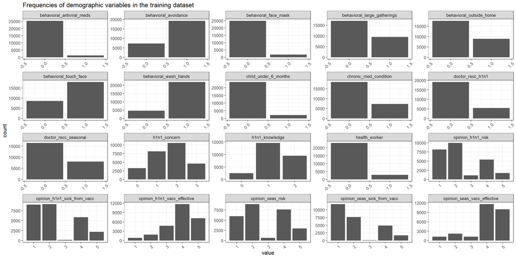

```r
training %>%
  select(h1n1_concern:opinion_seas_sick_from_vacc)%>%
  gather() %>%
  ggplot(aes(value)) +
    facet_wrap(~ key, scales = "free") +
    geom_bar()+
    ggtitle("Frequencies of demographic variables in the training dataset")+
    theme(text = element_text(size=12), axis.text.x = element_text(angle=45, hjust=1))
```

It might be possible to reduce the number of variables if we combine the behavioral variables together such that this new variable will indicate the number of safe behaviors a respondent adhered to. A “behavioral” variable could just add variables from behavioral_antiviral_meds to behavioral_touch_face.

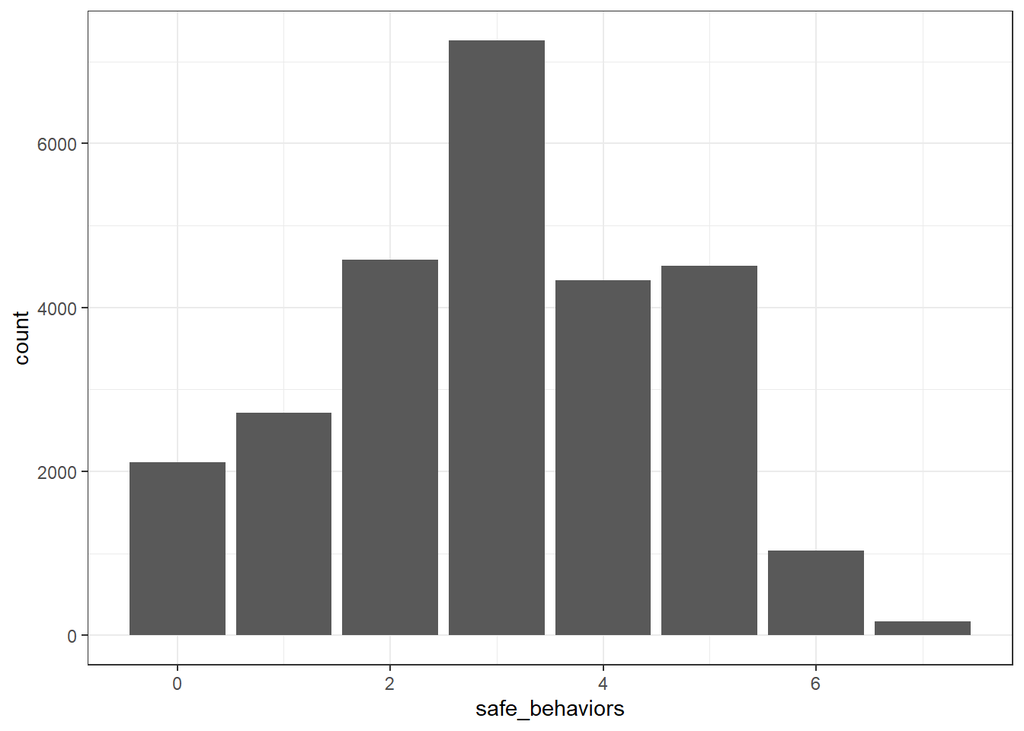

```r
training %>%
  select(behavioral_antiviral_meds:behavioral_touch_face) %>%
  mutate(safe_behaviors=rowSums(.,na.rm=TRUE))%>%
  ggplot(aes(x=safe_behaviors))+
  geom_bar()
```

```r
newvariable1 <- training %>%
  select(behavioral_antiviral_meds:behavioral_touch_face) %>%
  mutate(safe_behaviors=rowSums(.,na.rm=TRUE))%>%
  select(-behavioral_antiviral_meds:-behavioral_touch_face)

training$safe_behaviors <- newvariable1$safe_behaviors
```

It looks like this newly created variable is pretty normally distributed. We have to note that this new variable will use 0 instead of NA. 561 rows would be removed if we use na.rm=FALSE.

I’m not sure if we want to go this route but behavioral variables are probably going to be important for both h1n1_vaccine and seasonal_vaccine response variables.

```r
summary(glm(seasonal_vaccine~safe_behaviors,data=training,family="binomial"))
```

```
##
## Call:
## glm(formula = seasonal_vaccine ~ safe_behaviors, family = "binomial",
##     data = training)
##
## Deviance Residuals:
##    Min      1Q  Median      3Q     Max
## -1.392  -1.117  -0.927   1.240   1.450
##
## Coefficients:
##                Estimate Std. Error z value Pr(>|z|)
## (Intercept)     -0.6224     0.0269   -23.2   <2e-16 ***
## safe_behaviors   0.1592     0.0078    20.4   <2e-16 ***
## ---
## Signif. codes:  0 '***' 0.001 '**' 0.01 '*' 0.05 '.' 0.1 ' ' 1
##
## (Dispersion parameter for binomial family taken to be 1)
##
##     Null deviance: 36897  on 26706  degrees of freedom
## Residual deviance: 36472  on 26705  degrees of freedom
## AIC: 36476
##
## Number of Fisher Scoring iterations: 4
```

```r
summary(glm(h1n1_vaccine~safe_behaviors,data=training,family="binomial"))
```

```
##
## Call:
## glm(formula = h1n1_vaccine ~ safe_behaviors, family = "binomial",
##     data = training)
##
## Deviance Residuals:
##    Min      1Q  Median      3Q     Max
## -0.852  -0.725  -0.649  -0.580   1.933
##
## Coefficients:
##                Estimate Std. Error z value Pr(>|z|)
## (Intercept)    -1.69937    0.03390   -50.1   <2e-16 ***
## safe_behaviors  0.12467    0.00946    13.2   <2e-16 ***
## ---
## Signif. codes:  0 '***' 0.001 '**' 0.01 '*' 0.05 '.' 0.1 ' ' 1
##
## (Dispersion parameter for binomial family taken to be 1)
##
##     Null deviance: 27625  on 26706  degrees of freedom
## Residual deviance: 27449  on 26705  degrees of freedom
## AIC: 27453
##
## Number of Fisher Scoring iterations: 4
```